# 111-2 專題製作

```r
# 紅樓夢

# 安裝文字雲所需套件
#install.packages("tm")
#install.packages("wordcloud")

# 安裝相關係數可視化套件
#install.packages("corrplot")

# 安裝UI套件
#install.packages("shiny")

# 安裝jaccard套件
#install.packages("vegan")
```

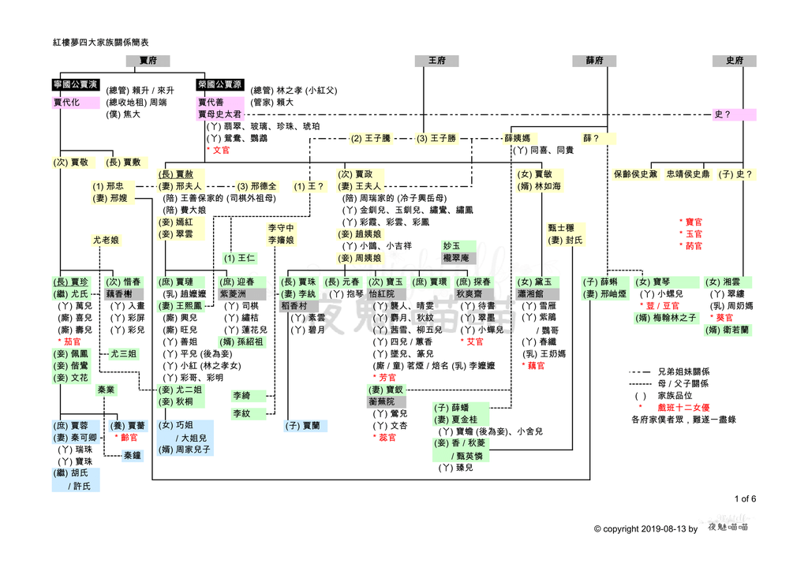

```r
# 自定義檔名函數
file_name_function = function(i){
  if (i < 10)
    file_name <- paste0("紅樓夢_第", 0, 0, i, "回")
  else if (i < 100)
    file_name <- paste0("紅樓夢_第", 0, i, "回")
  else
    file_name <- paste0("紅樓夢_第", i, "回")
  return(file_name)
}

# 字數統計函數
stat_words <- function(file_name){
  returnValue(sum(nchar(gsub("[，。！？：「」；《》『』——　 【、】1234567890]", "", gsub("\\[", " ", gsub("\\]", " ", gsub("-", " ", gsub("\\“\\”\\〝\\〞", " ", file_name))))))))
}

# 統計出現幾次特定文字函數
stat_name <- function(name_matrix, num.hei, name){ # name_matrix <- 欲統計的字詞, num.hei <- 總回數, name <- 儲存的矩陣

  # 名稱的替代(方便處理)
  name_matrix_change <- paste("person_", 1:length(name_matrix), "~", sep = "")
  name_matrix_change2 <- paste("person_", 1:length(name_matrix), sep = "")

  # 創建矩陣存放各章節人物出現次數
  name <- matrix(0, nrow = length(name_matrix), ncol = num.hei, dimnames = list(name_matrix, c(1:num.hei)))

  for (chapter in 1:num.hei){
    for (i in 1:length(name_matrix)){
      temp_store_name <- gsub(name_matrix[i], name_matrix_change[i], get(file_name_function(chapter)), fixed = TRUE) # 替換人物名稱並存入x
      temp_store_name1 <- strsplit(temp_store_name, "~") # 切割字串並以"~"分割
      name[i, chapter] <- length(grep(name_matrix_change2[i], temp_store_name1[[1]])) # 計算字串被切割幾次並儲存到name
    }
  }
  return(name)
}

# 文字雲 自訂函數
library(tm)
library(wordcloud)
cloud <- function(input_array, cloud_title) { # imput_array <- 資料, cloud_title <- 文字雲標題
  wordcloud(names(input_array), input_array, scale = c(4,1), random.order = FALSE, rot.per = 0.1, min.freq = 1, colors = rainbow (40)) #文字雲描述出現次數
  title(cloud_title)
}
# words 參數指定需要繪製詞云的詞；freq 參數指定每個詞的頻率；scale 參數控制字體大小；min.freq 參數指定至少需要出現的次數；random.order 參數控制是否隨機排列詞；rot.per 參數控制字體旋轉的比例；colors 參數指定顏色；... 為其他附加參數

# MDS 自訂函數
mds <- function(data_matrix, title_1, title_2){
  # 計算標準化的 MDS 坐標
  dat <- sweep(data_matrix, 2, colMeans(data_matrix))
  dat <- sweep(dat, 2, sqrt(diag(var(dat))), "/")
  loc <- cmdscale(dist(dat))
  x <- loc[ ,1]
  y <- loc[ ,2]
  w <- rownames(loc)

  # 繪製沒有重疊且所有單詞可視圖
  plot(x, y, type = "n", xlim = c(min(loc[ ,1]) - 5, max(loc[ ,1]) +5), ylim = c(min(loc[ ,2]) - 5, max(loc[ ,2]) + 5))
  lay <- wordlayout(x, y, w, xlim = c(min(loc[ ,1]) - 5, max(loc[ ,1]) +5), ylim = c(min(loc[ ,2]) - 5, max(loc[ ,2]) + 5))
  text(lay[ ,1], lay[ ,2], w)
  title(title_1)

  # 注意部分單詞僅部分可見
  textplot(x, y, w)
  title(title_2)
}

#jaccard自訂函數
#Jaccard係數是用來衡量兩個集合的相似度。它的計算方法是將兩個集合的交集除以它們的聯集，結果介於0和1之間，數值越大，表示集合之間的相似度越高。
library(vegan)
jaccard <- function(data_matrix, title_1, title_2){
  temp <- vegdist(data_matrix, method = "jaccard")
  temp <- as.matrix(temp)
    print(temp)
  mds(temp, title_1, title_2)
}

# 統計最多的前number名函數
top_stat <- function(input_matrix, output_character, number){
  output_character <- sort(apply(input_matrix, 1, sum), decreasing = TRUE)
  output_character <- output_character[1:number]
  return(output_character)
}
```

```r
# 將所有章節輸入R
for (i in 1:120){
  file_name <- file_name_function(i)
  assign(file_name, readLines(paste0(file_name, ".txt")))
  temp <- get(file_name)
  for (j in 2:length(get(file_name))){
  temp[1] <- paste0(temp[1], temp[j])
  }
  assign(file_name, temp[1])
}

# 各章節字數統計
words_per_chapter <- matrix(0, ncol = 120, dimnames = list("words", c(1:120)))
for (i in 1:120){
  words_per_chapter[1,i] <- stat_words(get(file_name_function(i)))
}
print(words_per_chapter) # 測試字數輸出
```

```
         1    2    3    4    5    6    7    8    9   10   11   12   13   14   15   16   17   18   19   20   21   22   23
words 6823 5066 7261 5157 6268 6292 6495 5711 4927 4464 5124 3657 4445 4836 4377 6604 6619 7281 7920 4380 5177 5946 4699
        24   25   26   27   28   29   30   31   32   33   34   35   36   37   38   39   40   41   42   43   44   45   46
words 7388 7129 6324 5523 8162 7492 5047 6230 5081 4202 6349 6898 5911 7843 4816 5494 7747 5695 6567 5818 5828 6711 7166
        47   48   49   50   51   52   53   54   55   56   57   58   59   60   61    62   63   64   65   66   67   68   69
words 6323 5768 6395 5964 5986 7190 7093 7616 7099 7387 9771 5937 4234 6313 5770 10277 9661 8477 5987 4402 8038 6491 6264
        70   71   72   73   74   75   76   77   78   79   80   81   82   83   84   85   86   87   88   89   90   91   92
words 5496 7867 6575 6535 9657 8336 6437 9279 9270 4200 5982 6027 7365 7075 6752 7007 5837 5735 5866 5229 5419 4683 6129
        93   94   95   96   97   98   99  100  101  102  103  104  105  106  107  108  109  110  111  112  113  114  115
words 5648 7213 5588 5917 8638 5133 5244 4958 6990 4303 6041 5451 4723 5037 5503 6139 7978 5932 6393 6133 6063 4367 6079
       116  117  118  119  120
words 5999 6729 6623 8346 6612
```

```r
# 定義欲探勘之章回
start_file <- 1 # 起始章節
end_file <- 120 # 結束章節

total_words <- 0
cat(paste(paste("起始章節：", file_name_function(start_file)), paste("結束章節：", file_name_function(end_file)), sep = '\n'))
```

```
起始章節： 紅樓夢_第001回
結束章節： 紅樓夢_第120回
```

```r
# 計算字數
if (start_file > end_file){
  print(paste("錯誤！起始章節不可大於結束章節！", start_file, ">" ,end_file))
  }else{
  for (i in start_file:end_file){
    total_words <- total_words + words_per_chapter[1,i]
  }
}
print(paste("共計", total_words, "字(去除空白與標點符號)"))
```

```
[1] "共計 755931 字(去除空白與標點符號)"
```

```r
# 統計虛詞出現次數
function_word <- c("之", "乎", "者", "也", "以", "而", "其", "爲", "為", "於", "于", "則", "所", "與", "何", "矣", "乃", "若", "及", "焉", "因", "且", "夫", "在", "哉", "將", "亦", "苟", "耳", "爾", "諸", "或", "兮", "兒", "了", "著", "嗎", "的", "方", "即", "皆", "仍", "故", "尚", "呀", "咧", "啊", "罷", "麼", "呢", "一", "不", "把", "讓", "向", "往", "是", "別", "好", "可", "便", "就", "但", "越", "再", "更", "比", "很", "偏")
function_word
```

```
 [1] "之" "乎" "者" "也" "以" "而" "其" "爲" "為" "於" "于" "則" "所" "與" "何" "矣" "乃" "若" "及" "焉" "因" "且" "夫"
[24] "在" "哉" "將" "亦" "苟" "耳" "爾" "諸" "或" "兮" "兒" "了" "著" "嗎" "的" "方" "即" "皆" "仍" "故" "尚" "呀" "咧"
[47] "啊" "罷" "麼" "呢" "一" "不" "把" "讓" "向" "往" "是" "別" "好" "可" "便" "就" "但" "越" "再" "更" "比" "很" "偏"
```

```r
# 定義回數 120回
num.hei <- 120

# 統計出現次數函數
function_word.stat <- 0 # 宣告有name的存在
function_word.stat <- stat_name(function_word, num.hei, function_word.stat) # 將結果存入function_word.stat
print("各回出現的虛詞數量")
```

```
[1] "各回出現的虛詞數量"
```

```r
apply(function_word.stat,2,sum)
```

```
   1    2    3    4    5    6    7    8    9   10   11   12   13   14   15   16   17   18   19   20   21   22   23   24
1227  973 1293  942 1072 1334 1320 1086  927  959 1107  642  764  727  751 1181 1112 1057 1584  857  967 1147  783 1447
  25   26   27   28   29   30   31   32   33   34   35   36   37   38   39   40   41   42   43   44   45   46   47   48
1361 1258 1087 1594 1456 1060 1342 1069  771 1303 1372 1183 1478  745 1124 1448 1135 1327 1179 1272 1312 1521 1207 1095
  49   50   51   52   53   54   55   56   57   58   59   60   61   62   63   64   65   66   67   68   69   70   71   72
1184  978 1170 1398 1135 1470 1408 1490 1946 1192  848 1333 1260 2017 1739 1535 1133  805 1682 1202 1149  980 1480 1357
  73   74   75   76   77   78   79   80   81   82   83   84   85   86   87   88   89   90   91   92   93   94   95   96
1322 1970 1656 1167 1946 1855  776 1190 1219 1386 1301 1334 1303 1068 1077 1126  988 1156  845 1235 1080 1454 1068 1225
  97   98   99  100  101  102  103  104  105  106  107  108  109  110  111  112  113  114  115  116  117  118  119  120
1681  959 1054 1078 1456  767 1180 1071  716  888  985 1151 1657 1271 1298 1185 1302  940 1282 1191 1398 1387 1686 1304
```

```r
print("各虛詞出現數量")
```

```
[1] "各虛詞出現數量"
```

```r
as.matrix(apply(function_word.stat,1,sum))
```

```
    [,1]
之  2151
乎    70
者   418
也  6117
以  1131
而   515
其   420
爲    13
為  1268
於   103
于   466
則   339
所   946
與  1061
何  1122
矣    65
乃   163
若  1036
及   286
焉    26
因  1980
且  1003
夫  1795
在  4010
哉    26
將  1159
亦   382
苟     2
耳   111
爾    24
諸   150
或   530
兮    81
兒  6092
了 21218
著  6184
嗎    78
的 15721
方  1172
```

[output cut: 15 more lines]

```
向   604
往   805
是 10148
別  1255
好  4048
可  1869
便  4074
就  3259
但   409
越   359
再  1256
更   614
比   538
很   251
偏   305
```

```r
#將前80回與後40回切割
function_word.1_80 <- function_word.stat[ ,1:80] # 前80回
function_word.1_40 <- function_word.stat[ ,1:40] # 前40回
function_word.41_80 <- function_word.stat[ ,41:80] # 中40回
function_word.81_120 <- function_word.stat[ ,81:120] # 後40回
```

```r
# 前80回虛詞出現次數長條圖
function_word.1_80.stat <- apply(function_word.1_80, 1, sum) # 將1-80所有回數合併
number <- 10 # 前number名
function_word.1_80.stat_10 <- sort(function_word.1_80.stat, decreasing = T)[1:number] # 降冪排列取前number名
function_word.1_80.stat_10
```

```
   了    的    不    一    是    也    兒    著    便    好
14268 10203 10046  8715  6402  4083  4028  3794  2598  2585
```

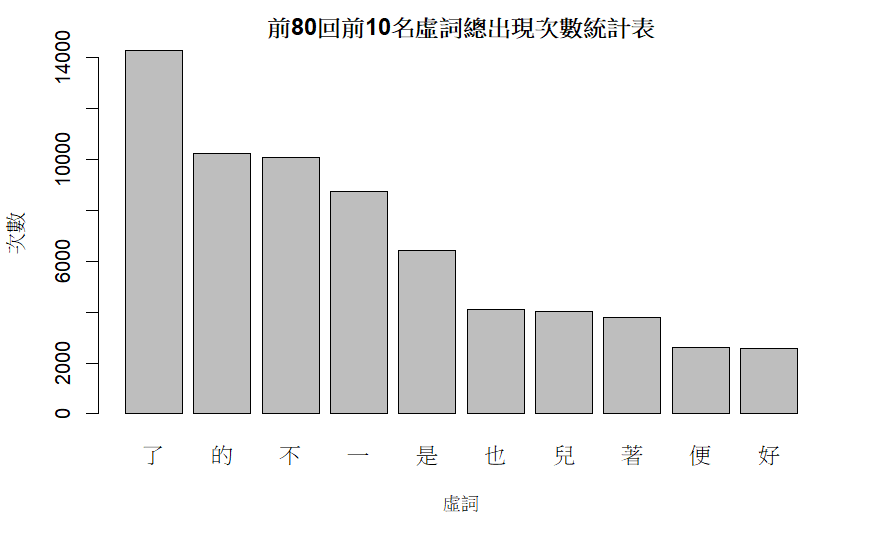

```r
barplot(function_word.1_80.stat_10, names.arg = names(function_word.1_80.stat_10), cex.names = 12.5/(as.numeric(number)), xlab = "虛詞", ylab = "次數", main = paste0("前80回", "前", number, "名虛詞總出現次數統計表"))
```

```r
# 後40回虛詞出現次數長條圖
function_word.81_120.stat <- apply(function_word.81_120, 1, sum) # 將81-120所有回數合併
number <- 10 # 前number名
function_word.81_120.stat_10 <- sort(function_word.81_120.stat, decreasing = T)[1:number] # 降冪排列取前number名
function_word.81_120.stat_10
```

```
  了   的   不   是   一   著   兒   也   在   便
6950 5518 5008 3746 3466 2390 2064 2034 1502 1476
```

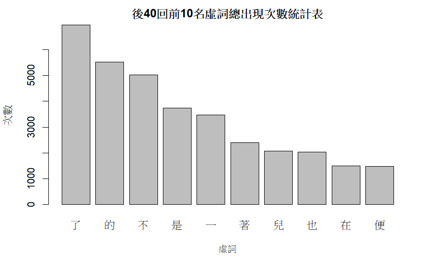

```r
barplot(function_word.81_120.stat_10, names.arg = names(function_word.81_120.stat_10), cex.names = 12.5/(as.numeric(number)), xlab = "虛詞", ylab = "次數", main = paste0("後40回", "前", number, "名虛詞總出現次數統計表"))
```

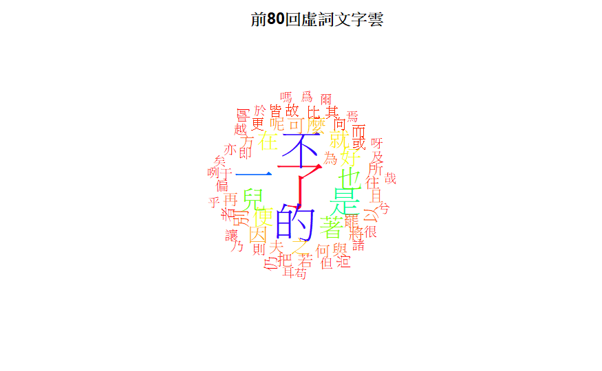

```r
# 虛詞文字雲
cloud(function_word.1_80.stat, "前80回虛詞文字雲") # 前80回虛詞文字雲
```

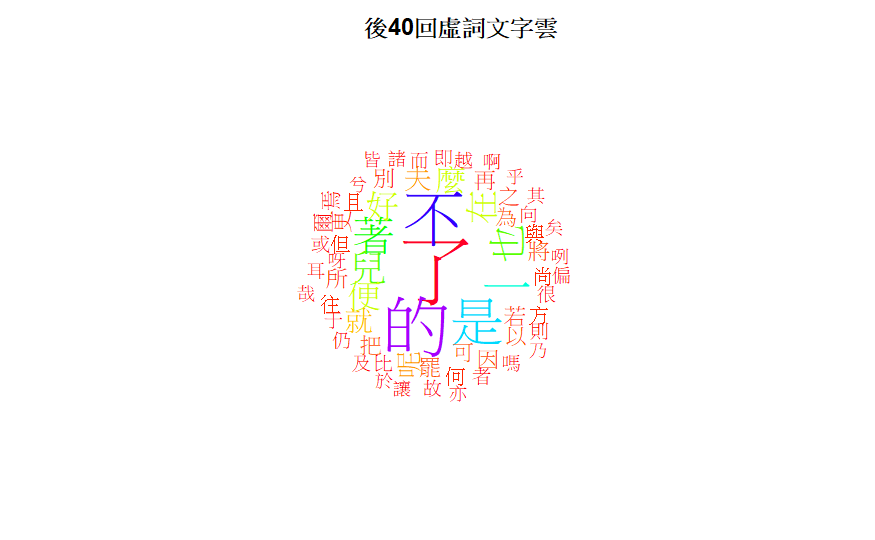

```r
cloud(function_word.81_120.stat, "後40回虛詞文字雲") # 後40回虛詞文字雲
```

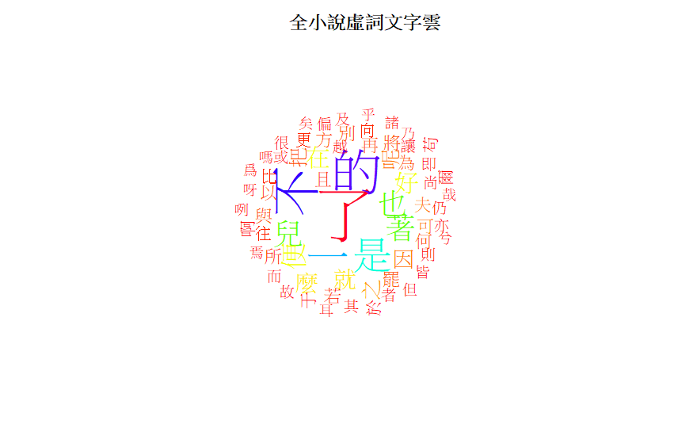

```r
cloud(apply(function_word.stat,1,sum), "全小說虛詞文字雲") # 全小說虛詞文字雲
```

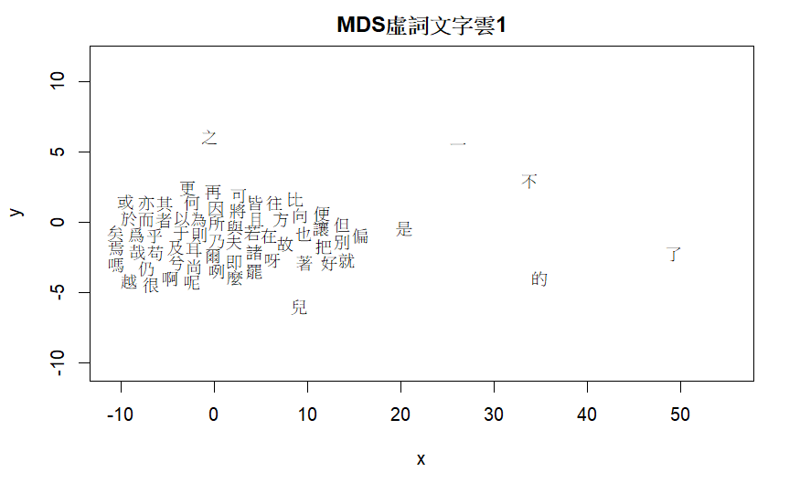

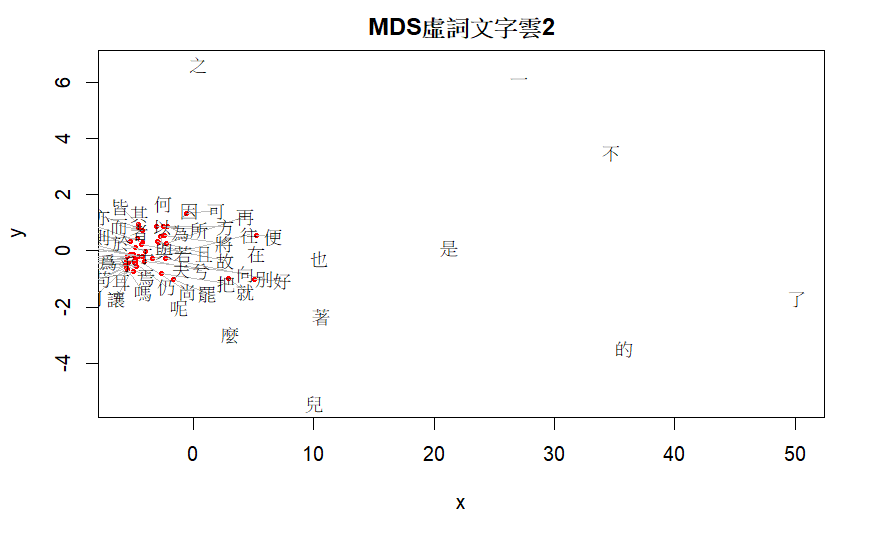

```r
# MDS 虛詞
mds(function_word.stat, "MDS虛詞文字雲1", "MDS虛詞文字雲2")
```

[output not shown]

[output cut: 51 more lines]

[output not shown]

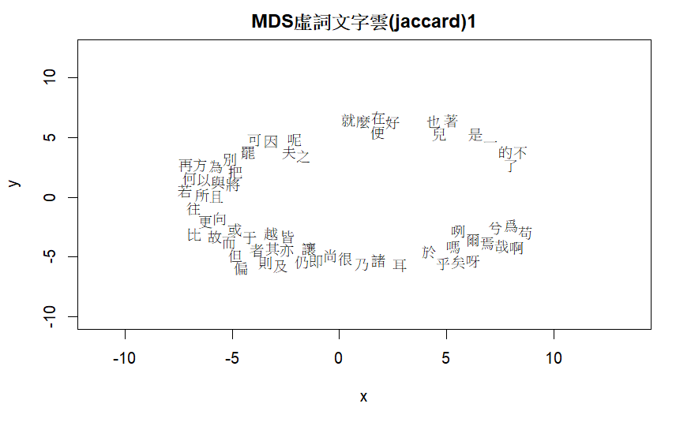

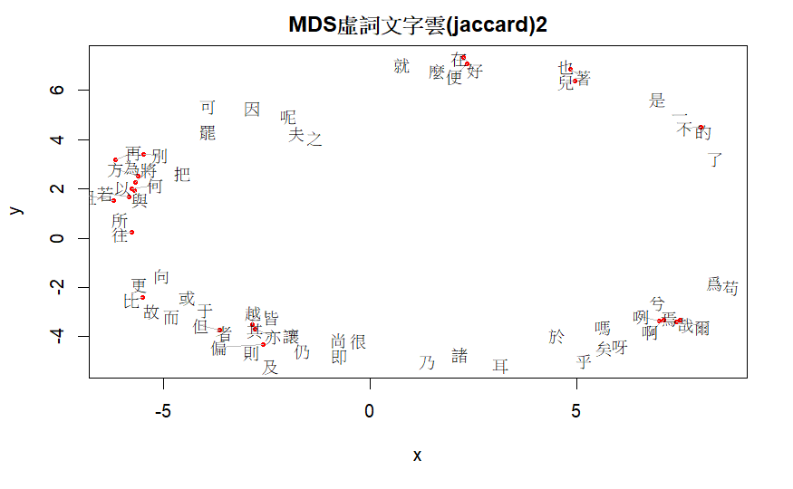

```r
# 虛詞jaccard方法
jaccard(function_word.stat, "MDS虛詞文字雲(jaccard)1", "MDS虛詞文字雲(jaccard)2")
```

```r
# 全小說前number名虛詞
funcion_word.top_10 <- 0 # 宣告存在
funcion_word.top_10 <- top_stat(function_word.stat, funcion_word.top_10, 10)
```

```r
# 拆分前中後各40回之虛字總數
function_word_sum <- data.frame(row.names = function_word)
function_word_sum[,1] <- apply(function_word.1_40, 1, sum)
function_word_sum[,2] <- apply(function_word.41_80, 1, sum)
function_word_sum[,3] <- apply(function_word.81_120, 1, sum)
function_word_sum[,4] <- apply(function_word.1_80, 1, sum)
colnames(function_word_sum) <- c("1-40回", "41-80回", "81-120回", "1-80回") # change column names of all the columns in the dataframe
function_word_sum
```

|  | 1-40回 | 41-80回 | 81-120回 | 1-80回 |
| --- | --- | --- | --- | --- |
| 之 | 915 | 912 | 324 | 1827 |
| 乎 | 13 | 21 | 36 | 34 |
| 者 | 168 | 141 | 109 | 309 |
| 也 | 1728 | 2355 | 2034 | 4083 |
| 以 | 304 | 440 | 387 | 744 |
| 而 | 226 | 174 | 115 | 400 |
| 其 | 214 | 149 | 57 | 363 |
| 爲 | 13 | 0 | 0 | 13 |
| 為 | 420 | 440 | 408 | 860 |
| 於 | 72 | 29 | 2 | 101 |

[output cut: 59 more lines]

```r
#虛字總數 取log長條圖
hui.number <- log(as.matrix(apply(function_word.stat,1,sum)))
sort(hui.number[,1])
```

```
       苟        爲        爾        焉        哉        咧        啊        呀        矣        乎        嗎        兮
0.6931472 2.5649494 3.1780538 3.2580965 3.2580965 3.5553481 3.5553481 4.0253517 4.1743873 4.2484952 4.3567088 4.3944492
       於        耳        諸        乃        即        很        仍        及        偏        讓        尚        則
4.6347290 4.7095302 5.0106353 5.0937502 5.5134287 5.5254529 5.6347896 5.6559918 5.7203118 5.7300998 5.7745515 5.8260001
       越        亦        皆        但        者        其        于        故        而        或        比        向
5.8833224 5.9454206 5.9763509 6.0137152 6.0354814 6.0402547 6.1441856 6.2085900 6.2441669 6.2728770 6.2878586 6.4035742
       更        往        所        且        若        與        何        以        把        將        方        別
6.4199949 6.6908423 6.8522426 6.9107508 6.9431224 6.9669671 7.0228681 7.0308575 7.0396603 7.0553128 7.0664670 7.1348909
       再        為        罷        夫        呢        可        因        之        就        麼        在        好
7.1356873 7.1451961 7.3304052 7.4927603 7.5131635 7.5331588 7.5908521 7.6736881 8.0891757 8.1155209 8.2965465 8.3059782
       便        兒        也        著        是        一        不        的        了
8.3123806 8.7147317 8.7188271 8.7297206 9.2250319 9.4076326 9.6193990 9.6627527 9.9626052
```

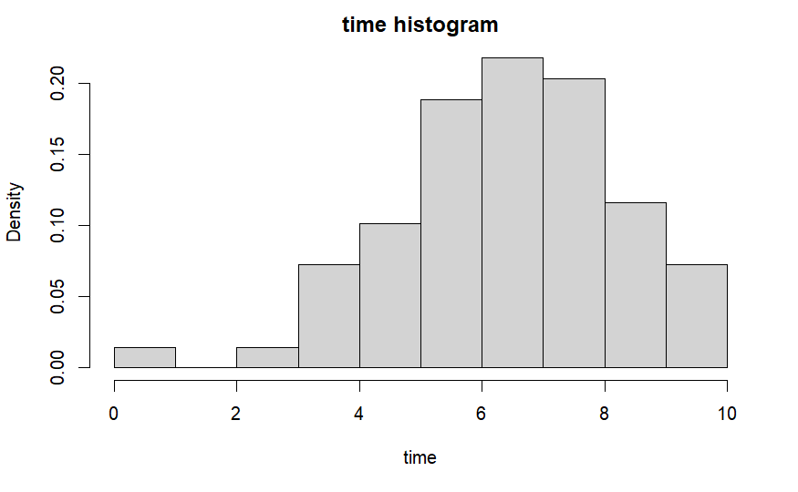

```r
hist(hui.number,
     freq = FALSE,
     main = "time histogram",
     xlab = "time"
     )
```

```r
# 對各情況進行 t-test
# 對兩列進行 t-test
function_word_t.test_1v41 <- t.test(function_word_sum$`1-40回`, function_word_sum$`41-80回`, paired = TRUE, alternative = "two.sided", var.equal = FALSE)
# 打印结果
print(function_word_t.test_1v41)
```

```
    Paired t-test

data:  function_word_sum$`1-40回` and function_word_sum$`41-80回`
t = -3.2244, df = 68, p-value = 0.001941
alternative hypothesis: true mean difference is not equal to 0
95 percent confidence interval:
 -209.06760  -49.22225
sample estimates:
mean difference
      -129.1449
```

```r
# 對兩列進行 t-test
function_word_t.test_1v81 <- t.test(function_word_sum$`1-40回`, function_word_sum$`81-120回`, paired = TRUE, alternative = "two.sided", var.equal = FALSE)
# 打印结果
print(function_word_t.test_1v81)
```

```
    Paired t-test

data:  function_word_sum$`1-40回` and function_word_sum$`81-120回`
t = -1.2746, df = 68, p-value = 0.2068
alternative hypothesis: true mean difference is not equal to 0
95 percent confidence interval:
 -105.6727   23.2959
sample estimates:
mean difference
      -41.18841
```

```r
# 對兩列進行 t-test
function_word_t.test_41v81 <- t.test(function_word_sum$`41-80回`, function_word_sum$`81-120回`, paired = TRUE, alternative = "two.sided", var.equal = FALSE)
# 打印结果
print(function_word_t.test_41v81)
```

```
    Paired t-test

data:  function_word_sum$`41-80回` and function_word_sum$`81-120回`
t = 2.7772, df = 68, p-value = 0.007078
alternative hypothesis: true mean difference is not equal to 0
95 percent confidence interval:
  24.75881 151.15424
sample estimates:
mean difference
       87.95652
```

```r
#perform Welch's two sample t-test
# 對兩列進行 t-test
function_word_t.test_1.80v81 <- t.test(function_word_sum$`1-80回`, function_word_sum$`81-120回`, paired = TRUE, alternative = "two.sided", var.equal = FALSE)
# 打印结果
print(function_word_t.test_1.80v81)
```

```
    Paired t-test

data:  function_word_sum$`1-80回` and function_word_sum$`81-120回`
t = 4.5646, df = 68, p-value = 2.158e-05
alternative hypothesis: true mean difference is not equal to 0
95 percent confidence interval:
  415.8393 1061.8129
sample estimates:
mean difference
       738.8261
```

```r
# 對兩列進行 t-test
function_word_t.test_1.40v1.80 <- t.test(function_word_sum$`1-40回`, function_word_sum$`1-80回`, paired = TRUE, alternative = "two.sided", var.equal = FALSE)
# 打印结果
print(function_word_t.test_1.40v1.80)
```

```
    Paired t-test

data:  function_word_sum$`1-40回` and function_word_sum$`1-80回`
t = -4.3384, df = 68, p-value = 4.874e-05
alternative hypothesis: true mean difference is not equal to 0
95 percent confidence interval:
 -1138.7855  -421.2435
sample estimates:
mean difference
      -780.0145
```

```r
# 分析虛詞前後字詞

num.hei <- 120

for(i in 1:length(funcion_word.top_10)){
  assign(paste0("function_word_",names(funcion_word.top_10[i])), 0)
  for(chapter in 1:num.hei){
    temp <- gsub(paste0(".*", names(funcion_word.top_10[i]), "(.{1}).*"), "\\1", get(file_name_function(chapter))) # 擷取後面一個字
    assign(paste0("function_word_",names(funcion_word.top_10[i])), c(get(paste0("function_word_",names(funcion_word.top_10[i]))), paste0(names(funcion_word.top_10[i]), temp)))
    temp <- gsub(paste0(".*(.{1})" , names(funcion_word.top_10[i]), ".*"), "\\1", get(file_name_function(chapter))) # 擷取前面一個字
    assign(paste0("function_word_",names(funcion_word.top_10[i])), c(get(paste0("function_word_",names(funcion_word.top_10[i]))), paste0(temp, names(funcion_word.top_10[i]))))
  }
  assign(paste0("function_word_",names(funcion_word.top_10[i])), get(paste0("function_word_",names(funcion_word.top_10[i])))[2:length(get(paste0("function_word_",names(funcion_word.top_10[i]))))])
}

# 將過長字串移除
for(i in 1:length(funcion_word.top_10)){
  for(j in 1:length(get(paste0("function_word_",names(funcion_word.top_10[i]))))){
    if(stat_words(get(paste0("function_word_",names(funcion_word.top_10[i])))[j]) > 2){
      temp <- get(paste0("function_word_",names(funcion_word.top_10[i])))
      temp[j] <- "NA"
      temp <- as.character(temp)
      assign(paste0("function_word_",names(funcion_word.top_10[i])), temp)
    }
  }
}

# 將重複字串移除
for(i in 1:length(funcion_word.top_10)){
  temp_1 <- ""
  temp <- get(paste0("function_word_",names(funcion_word.top_10[i])))
  for(j in 1:(length(temp)-1)){
    for(k in 2:length(temp)){
     if((temp[j] == temp[k]) && (j != k)){
        #print(paste(temp[j],temp[k],temp[j] == temp[k]))
        temp[k] <- ""
      }
    }
    if(stat_words(temp[j]) > 1){
      temp_1 <- c(temp_1, temp[j])
    }
  }
  temp_1 <- temp_1[-1]
  assign(paste0("function_word_",names(funcion_word.top_10[i])), temp_1)
}

# 將所組合之"詞"進行次數搜尋
for(i in 1:length(funcion_word.top_10)){
    assign(paste0("function_word_stat_",names(funcion_word.top_10[i])), 0)
    assign(paste0("function_word_stat_",names(funcion_word.top_10[i])), stat_name(get(paste0("function_word_",names(funcion_word.top_10[i]))), 120, get(paste0("function_word_stat_",names(funcion_word.top_10[i])))))
    # print(get(paste0("function_word_stat_",names(funcion_word.top_10[i]))))
}
```

```r
# 加總虛字前後之造詞並輸出前10
for(i in 1:length(funcion_word.top_10)){
  temp <- get(paste0("function_word_stat_",names(funcion_word.top_10[i])))
  assign(paste0("function_word_top_stat_",names(funcion_word.top_10[i])), 0)
  assign(paste0("function_word_top_stat_",names(funcion_word.top_10[i])), top_stat(temp, get(paste0("function_word_top_stat_",names(funcion_word.top_10[i]))), 10))
  print(get(paste0("function_word_top_stat_",names(funcion_word.top_10[i]))))
}
```

```
了一 去了 聽了 來了 見了 說了 了這 了他 罷了 好了
1706 1093 1051 1039  564  520  464  422  392  344
家的 的人 的事 我的 的話 來的 說的 里的 好的 的一
 695  626  460  444  444  441  414  309  267  248
也不 不知 不是 不得 不好 不過 不敢 不能 又不 不用
1452 1083  893  816  557  522  510  438  411  307
了一 一個 一面 有一 一時 這一 一回  ”一 那一 是一
1706 1538  834  454  443  412  374  347  295  293
不是 就是 只是 也是 是個 是我 這是 是這 是一 是他
 893  601  547  458  375  370  319  295  293  268
說著 著一 看著 著他 想著 跟著 著了 坐著 不著 笑著
 899  187  181  175  172  149  143  133  131  122
也不 也是 我也 也有 也沒 你也 人也 也就 們也 也罷
1452  458  428  331  289  190  178  174  165  146
平兒 姐兒 今兒 明兒 兒的 兒道 女兒 兒笑 兒也 哥兒
 695  605  301  239  237  216  200  161  145  143
便說 便是 便問 便叫 玉便 便命 人便 便道 便將 便不
 310  183  152  131  130  107  107  104   97   95
不好 好了  “好 好的 好些 才好 的好 了好 就好 是好
 557  344  268  267  191  174  168  151  111  110
```

```r
# 串聯以上資料
temp_1 <- 0 # 清空暫存變數
for(i in 1:length(funcion_word.top_10)){
  temp <- get(paste0("function_word_top_stat_",names(funcion_word.top_10[i])))
  temp_1 <- c(temp_1,temp)
}
function_word_all_top_stat <- temp_1[-1]
function_word_all_top_stat
```

```
了一 去了 聽了 來了 見了 說了 了這 了他 罷了 好了 家的 的人 的事 我的 的話 來的 說的 里的 好的 的一 也不 不知 不是 不得
1706 1093 1051 1039  564  520  464  422  392  344  695  626  460  444  444  441  414  309  267  248 1452 1083  893  816
不好 不過 不敢 不能 又不 不用 了一 一個 一面 有一 一時 這一 一回  ”一 那一 是一 不是 就是 只是 也是 是個 是我 這是 是這
 557  522  510  438  411  307 1706 1538  834  454  443  412  374  347  295  293  893  601  547  458  375  370  319  295
是一 是他 說著 著一 看著 著他 想著 跟著 著了 坐著 不著 笑著 也不 也是 我也 也有 也沒 你也 人也 也就 們也 也罷 平兒 姐兒
 293  268  899  187  181  175  172  149  143  133  131  122 1452  458  428  331  289  190  178  174  165  146  695  605
今兒 明兒 兒的 兒道 女兒 兒笑 兒也 哥兒 便說 便是 便問 便叫 玉便 便命 人便 便道 便將 便不 不好 好了  “好 好的 好些 才好
 301  239  237  216  200  161  145  143  310  183  152  131  130  107  107  104   97   95  557  344  268  267  191  174
的好 了好 就好 是好
 168  151  111  110
```

```r
# 排序function_word_all_top_stat
function_word_all_top_stat <- sort(function_word_all_top_stat, decreasing = T)[-1] # 刪除重複
function_word_all_top_stat
```

```
了一 一個 也不 也不 去了 不知 聽了 來了 說著 不是 不是 一面 不得 家的 平兒 的人 姐兒 就是 見了 不好 不好 只是 不過 說了
1706 1538 1452 1452 1093 1083 1051 1039  899  893  893  834  816  695  695  626  605  601  564  557  557  547  522  520
不敢 了這 的事 也是 也是 有一 我的 的話 一時 來的 不能 我也 了他 說的 這一 又不 罷了 是個 一回 是我  ”一 好了 好了 也有
 510  464  460  458  458  454  444  444  443  441  438  428  422  414  412  411  392  375  374  370  347  344  344  331
這是 便說 里的 不用 今兒 那一 是這 是一 是一 也沒 是他  “好 好的 好的 的一 明兒 兒的 兒道 女兒 好些 你也 著一 便是 看著
 319  310  309  307  301  295  295  293  293  289  268  268  267  267  248  239  237  216  200  191  190  187  183  181
人也 著他 也就 才好 想著 的好 們也 兒笑 便問 了好 跟著 也罷 兒也 著了 哥兒 坐著 不著 便叫 玉便 笑著 就好 是好 便命 人便
 178  175  174  174  172  168  165  161  152  151  149  146  145  143  143  133  131  131  130  122  111  110  107  107
便道 便將 便不
 104   97   95
```

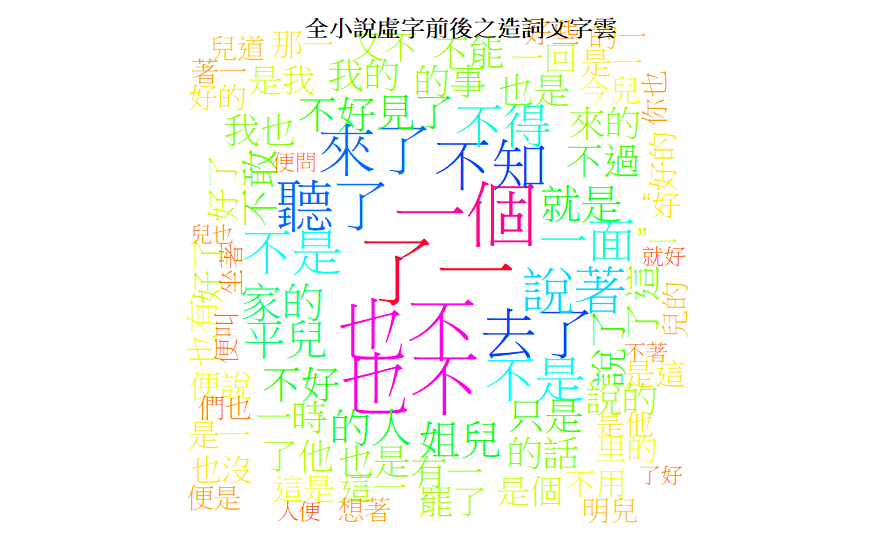

```r
cloud(function_word_all_top_stat, "全小說虛字前後之造詞文字雲") # 全小說虛字前後之造詞文字雲
```

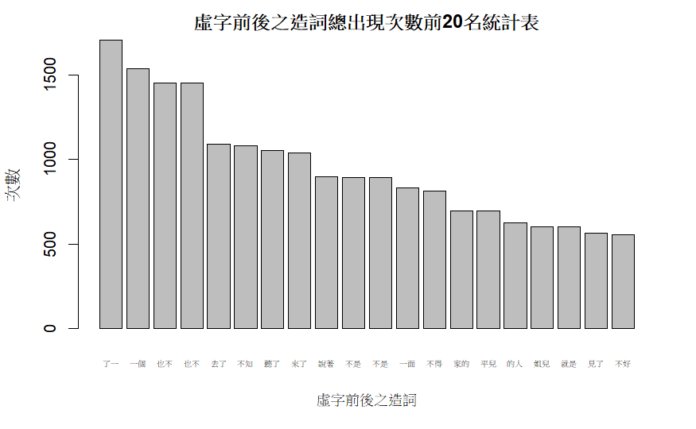

```r
# 長條圖
barplot(function_word_all_top_stat[1:20], names.arg = names(function_word_all_top_stat[1:20]), cex.names = 5/(as.numeric(number)), xlab = "虛字前後之造詞", ylab = "次數", main = paste0("虛字前後之造詞總出現次數前20名統計表"))
```

### 參考資料

曹雪芹, & 高鶚. (約為乾隆初年). 紅樓夢 (程偉元, Ed.). 維基文庫. https://zh.wikisource.org/zh-hant/紅樓夢

喵喵. (2020, May 4). ▌讀 | CN ▌紅樓夢 | 人物關係表 | 四大家族 | 寶玉、黛玉、寶釵血緣關係 | 5 分鐘弄懂紅樓夢人物關係 | 淺談紅樓夢 | 2022. NightelfMeowMeow. https://nightelfmeowmeow.com/378/1105014-reading-cn-novel-dream-of-the-red-chamber-family-tree/

文言/虛詞. (2023, February 18). 維基教科書. https://zh.wikibooks.org/zh-tw/%E6%96%87%E8%A8%80/%E8%99%9B%E8%A9%9E

上海數據分析網. (2017, October 27). 數據分析看《紅樓夢》作者. 每日頭條. https://kknews.cc/zh-tw/culture/z2m9mgl.html

余清祥. (1998, May). 統計在紅樓夢的應用. 政大機構典藏. http://nccur.lib.nccu.edu.tw/handle/140.119/103224

杜協昌. (2012, November 30). 利用文本採礦探討《紅樓夢》的後四十回作者爭議. DocuSky 數位人文學術研究平台. https://docusky.org.tw/Paper/DADH2012_Text_Mining_DreamOfTheRedChamber/slide.pdf

陳佳琳. (2021, October). 以文風指標分析《紅樓夢》的作者爭議問題 Solving the Author Problem of “Dream of the Red Chamber” with the Writing Style Indicator (楊昌彪, Ed.). 臺灣博碩士論文知識加值系統. https://hdl.handle.net/11296/vvu95e

李賢平.《紅樓夢》成書新說. 復旦學報(社會科學版). 1987年第5期.

MDS - wordcloud 參考網站 https://rdrr.io/rforge/wordcloud/man/wordlayout.html

jaccard 參考網站 https://www.r-bloggers.com/2021/11/how-to-calculate-jaccard-similarity-in-r/